# Speed: v = s/t

Beta · Lesson 11/09 · IGCSE 0653

Physics · IGCSE Combined Science 0653

## Warm-up

5 minutes

- You and a friend leave Piazza Maggiore together.
- One walks, one cycles, one drives.
- Who arrives first — and how do we know, without a stopwatch?

DEFINITION

v=\dfrac{s}{t}

s = distance (m) t = time (s) v = speed (m/s)

Common unit: km/h  
km/h → m/s: ÷3.6 m/s → km/h: ×3.6

## Worked example — direct

Bologna → Firenze ≈ 100 km, in 1 hour

1

v=s/t

2

v=100\ \mathrm{km}/1\ \mathrm{h}=100\ \mathrm{km/h}

average speed

3

100\div 3.6\approx 27.8\ \mathrm{m/s}

convert to SI units

## Worked example — inverse

Cyclist at 20 km/h, distance 5 km

1

t=s/v

2

t=5/20=0.25\ \mathrm{h}

not minutes yet!

0.25 h ≠ 25 minutes → it's 15 minutes.

## Try it yourself (1/2)

- 1. A car travels 180 km in 2 h — find v in km/h and in m/s.
- 2. A runner moves at 4 m/s for 10 minutes — how many metres does she cover?

## Try it yourself (2/2)

- 3. A train travels at 120 km/h — how long to cover 300 km? Give hours and minutes.
- 4. Convert 15 m/s into km/h.

02

## Distance–time graphs

## Reading a distance–time graph

- Slope of the line = speed
- Steeper line → faster motion
- Flat line → object is stationary
- Downward slope → moving back the other way

## Read the graph — Cambridge IGCSE style

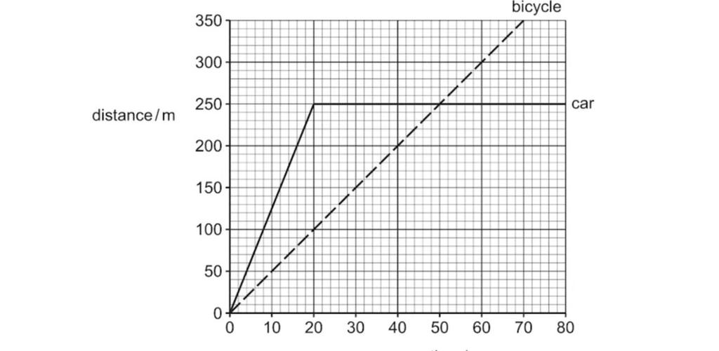

- (i) Use Fig. 9.1 to describe the car journey.
- (ii) State the time at which the bicycle passes the car.

Source: Cambridge IGCSE Combined Science 0653, past paper (Fig. 9.1). The car and bicycle start from the same point, same direction, same road.

03

## Quick check

## Quick check — multiple choice

A man climbs up a vertical cliff that is 60 m high. He takes two hours to reach the top. What is the average vertical speed of the man?

1. 0.0083\ \mathrm{m/s}
2. 0.50\ \mathrm{m/s}
3. 30\ \mathrm{m/s}
4. 120\ \mathrm{m/s}

v = 60 m ÷ (2×3600 s) = 60/7200 ≈ 0.0083 m/s. Il trabocchetto è dimenticare di convertire le ore in secondi.

Source: Cambridge IGCSE Combined Science 0653, past paper.

## Quick check — calculation

Answer in m/s

- A cyclist travels 30 km in 2 hours.
- What is her average speed?

## Summary

- Average speed: v = s/t
- SI unit m/s · common unit km/h · convert ÷ or × 3.6
- On a distance–time graph, slope = speed